# Missing Values

Ji Hun Lee

May 24, 2020

#### Import Libraries

```r
library(VIM) # tropical atmospheric ocean data
library(mice) # multivariate imputation by chained equations
library(DMwR) # centralImputation, knnImputation, manyNAs
library(tidyverse) # data wrangling operations
library(fivethirtyeight) # biopics dataset
```

# Why Missing Data is a Problem

Models cannot understand missing values. Without appropriate remedies, we have to resort removing the rows containing NA value, and this can create bias in our model.

# Why Missing Data Happen

1. Nonresponse in surveys
2. Technical issues with data collecting equipment
3. Joining data from difference sources

# Example Datasets

```r
data(tao) # Tropical Atmosphere Ocean
data(biopics) # raw data from Straight Outta Compton
data(airquality) # Daily air quality measurements in New York, May to September 1973
```

# Inspecting Missingness in Data

Missing Data in R is encoded as NaN, NA, Inf. Replace empty string “”, -1, #N/A, ‘missing’ with NA in R.

Is there any missing data?

```r
any(is.na(tao)) # check for any NA in dataframe
```

```
## [1] TRUE
```

```r
sum(is.na(tao)) # how many NA?
```

```
## [1] 177
```

How many missing values does each column contain?

```r
colSums(is.na(tao)) # how many missing per column
```

```
##             Year         Latitude        Longitude Sea.Surface.Temp
##                0                0                0                3
##         Air.Temp         Humidity            UWind            VWind
##               81               93                0                0
```

Summary statistics of data:

```r
summary(tao)
```

```
##       Year         Latitude        Longitude      Sea.Surface.Temp
##  Min.   :1993   Min.   :-5.000   Min.   :-110.0   Min.   :21.60
##  1st Qu.:1993   1st Qu.:-2.000   1st Qu.:-110.0   1st Qu.:23.50
##  Median :1995   Median :-1.000   Median :-102.5   Median :26.55
##  Mean   :1995   Mean   :-1.375   Mean   :-102.5   Mean   :25.86
##  3rd Qu.:1997   3rd Qu.: 0.000   3rd Qu.: -95.0   3rd Qu.:28.21
##  Max.   :1997   Max.   : 0.000   Max.   : -95.0   Max.   :30.17
##                                                   NA's   :3
##     Air.Temp        Humidity         UWind            VWind
##  Min.   :21.42   Min.   :71.60   Min.   :-8.100   Min.   :-6.200
##  1st Qu.:23.26   1st Qu.:81.30   1st Qu.:-5.100   1st Qu.: 1.500
##  Median :24.52   Median :85.20   Median :-3.900   Median : 2.900
##  Mean   :25.03   Mean   :84.43   Mean   :-3.716   Mean   : 2.636
##  3rd Qu.:27.08   3rd Qu.:88.10   3rd Qu.:-2.600   3rd Qu.: 4.100
##  Max.   :28.50   Max.   :94.80   Max.   : 4.300   Max.   : 7.300
##  NA's   :81      NA's   :93
```

Find dataframe without missing values:

```r
ind <- which(is.na(tao)) # which rows contain NA?
ind2 <- complete.cases(tao) # rows with no missing values
tao[ind,] = na.omit(tao) # na.omit is the same as na.exclude()
```

Group missing values in column 1 by column 2

```r
# Calculate the number of missing values in air_temp per year
tao %>%
  group_by(Year) %>%
  summarize(num_miss = sum(is.na(Air.Temp)))
```

```
## # A tibble: 3 x 2
##    Year num_miss
##   <int>    <int>
## 1  1993        4
## 2  1997       77
## 3    NA     3319
```

# Types of Missingness

There are three types of missingness.

#### Missing Completely at Random:

Location of missing valuesin the dataset are completely random, they do not depend on any other data; reason for missingness is purely random.

1. In a dataset containing school exam results, some children lack the result because they were ill and did not attend the test.
2. While manually labeling the data, the labeler accidentally left some entries missing.
3. A weather sensor is measuring temperature and sending the data to a database. There are some missing entries in the database for when the sensor broke down.

#### Missing at Random:

If the reason for missingness can be explained by another variable, it’s MAR.

1. You are tracking your website visitors’ location. If yhey are using a VPN, tracking is unrelaible and you often record missing values.
2. In a healthy survey, you see missing data on weight. You suspect the values for the weight variable to be missing for one gender over another

3.There are some missing temperature values in the database for when the sensor was switched offfor maintenance.As the maintenance team never work on the weekends,the locations of missing values depend on the day ofthe week.

#### Missing Not at Random:

If the reason for missingness depends on the missing value itself, it’s MNAR.

1. It is know that far right supporters tend not to admit it in the election polls
2. In surveys, rich people are more likely to not disclose their income
3. When it’s extremely cold,the weather sensor freezes and stops working. So, it does not record very low temperatures. Thus,the locations of missing values in the temperature variable depend on the values of this variable themselves.

# Testing Missingness

We can test the type of missingness and visualize patterns of missingness with graphs (aggregation plot, spine plot, mosaic plot).

### t-test

t.test to check the null hypothesis MCAR by comparing the mean of two groups

```r
# Create a dummy variable for missing earnings
biopics <- biopics %>%
  mutate(missing_earnings = is.na(box_office))

# Pull the missing earnings dummy for males
missing_earnings_males <- biopics %>%
  filter(subject_sex == 'Male') %>%
  pull(missing_earnings)

# Pull the missing earnings dummy for females
missing_earnings_females <- biopics %>%
  filter(subject_sex == 'Female') %>%
  pull(missing_earnings)

# Run the t-test
t.test(missing_earnings_males,missing_earnings_females)
```

```
##
##  Welch Two Sample t-test
##
## data:  missing_earnings_males and missing_earnings_females
## t = 1.1116, df = 294.39, p-value = 0.2672
## alternative hypothesis: true difference in means is not equal to 0
## 95 percent confidence interval:
##  -0.03606549  0.12969214
## sample estimates:
## mean of x mean of y
## 0.4366438 0.3898305
```

### Problem with t-test:

1. Detecting missing data patterns with statistical tests can be cumbersome.
2. t-test comes with many assumtions about data.
3. Inferences based upon p-values are prone to problems (choosing significance level and p-hacking).

### Aggregation plot

The aggregation plot provides the answer to the basic question one may ask about an incomplete dataset: in which combinations of variables the data are missing, and how often? It is very useful for gaining a high-level overview of the missingness patterns. For example, it makes it immediately visible if there is some combination of variables that are often missing together, which might suggest some relation between them.

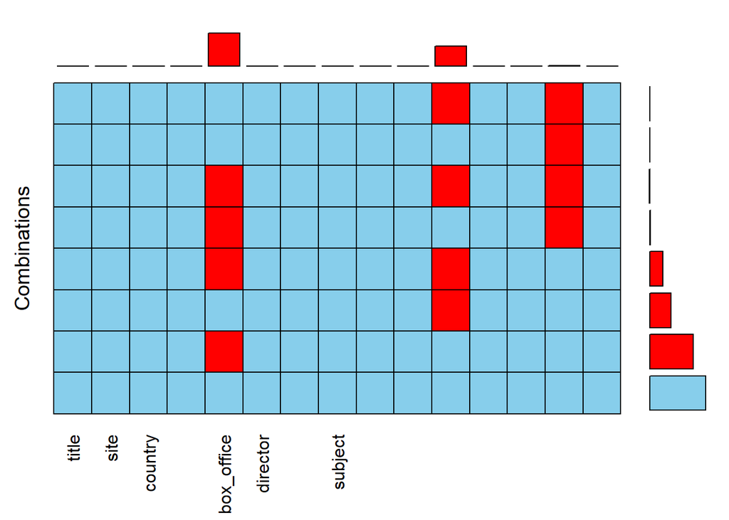

```r
# Draw an aggregation plot of biopics
biopics %>%
    aggr(combined = TRUE, numbers = TRUE)
```

### Margin Plot

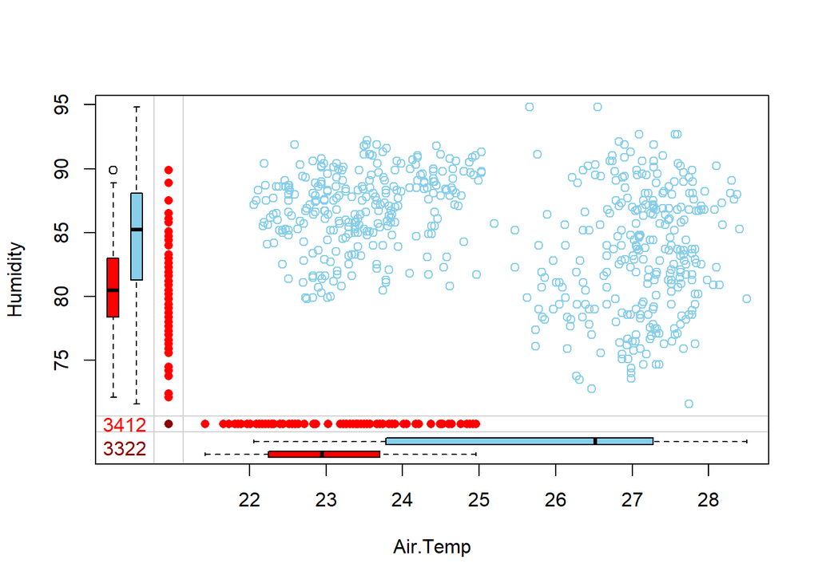

```r
marginplot(tao[,c("Air.Temp", "Humidity")])
```

### Spine Plot

If you are interested in the interaction between specific variables, a spine plot is the way to go. It allows you to study the percentage of missing values in one variable for different values of the other, which is conceptually very similar to the t-tests.

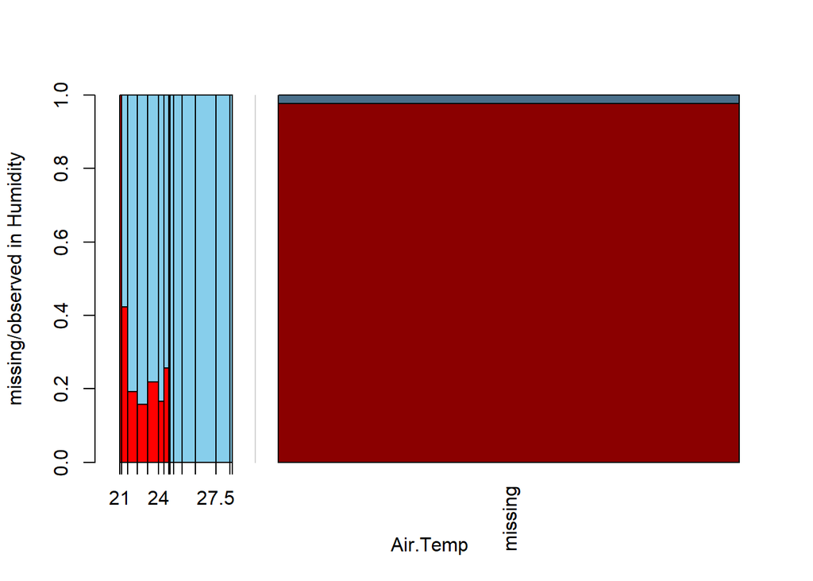

```r
spineMiss(tao[, c("Air.Temp", "Humidity")])
```

### Mosaic Plot

The spine plot allows you to study missing data patterns between two variables at a time. This idea is generalized to more variables in the form of a mosaic plot. First, start by creating a dummy variable indicating whether the United States was involved in the production of each movie. To do this, you will use the grepl() function, which checks if the string passed as its first argument is present in the object passed as its second argument. Then, draw a mosaic plot to see if the subject’s gender correlates with the amount of missing data on earnings for both US and non-US movies.

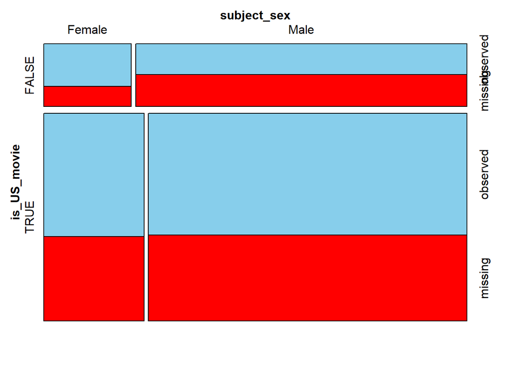

```r
# Prepare data for plotting and draw a mosaic plot
biopics %>%
    # Create a dummy variable for US-produced movies
    mutate(is_US_movie = grepl('US', country)) %>%
    # Draw mosaic plot
    mosaicMiss(highlight = 'box_office',
             plotvars = c('is_US_movie', 'subject_sex')) # remembering to pass variable names as stings.
```

Before you expand the output, notice how, for non-US movies, there is less missing data on earnings for movies featuring females. This doesn’t look MCAR!

# Imptation

Imputation is making an educated guess about what missing values may be.

# Donor-Based Imputation Methods

Missing values are filled in using other complete observations (they donate their data to missing values).

1. Mean-Based:

Mean imputation can sometimes work for time series, but should be careful on cross-sectional data because it destroys relationship between variables and provides no variance to data

```r
tao_imp <- tao %>%
  # Create a binary indicator for missing values in air_temp
  mutate(air_temp_imp = as.logical(ifelse(is.na(Air.Temp), 'TRUE', 'FALSE'))) %>%
  # Impute air_temp with its mean
  mutate(Air.Temp = ifelse(is.na(Air.Temp), mean(Air.Temp, na.rm = TRUE), Air.Temp))
head(tao_imp, 5)
```

```
##   Year Latitude Longitude Sea.Surface.Temp Air.Temp Humidity UWind VWind
## 1 1997        0      -110            27.59    27.15     79.6  -6.4   5.4
## 2 1997        0      -110            27.55    27.02     75.8  -5.3   5.3
## 3 1997        0      -110            27.57    27.00     76.5  -5.1   4.5
## 4 1997        0      -110            27.62    26.93     76.2  -4.9   2.5
## 5 1997        0      -110            27.65    26.84     76.4  -3.5   4.1
##   air_temp_imp
## 1        FALSE
## 2        FALSE
## 3        FALSE
## 4        FALSE
## 5        FALSE
```

Upon examining the tao data, you might have noticed that it also contains a variable called sea_surface_temp, which could reasonably be expected to be positively correlated with air_temp. If that’s the case, you would expect these two temperatures to be both high or both low at the same time. Imputing mean air temperature when the sea temperature is high or low would break this relation.

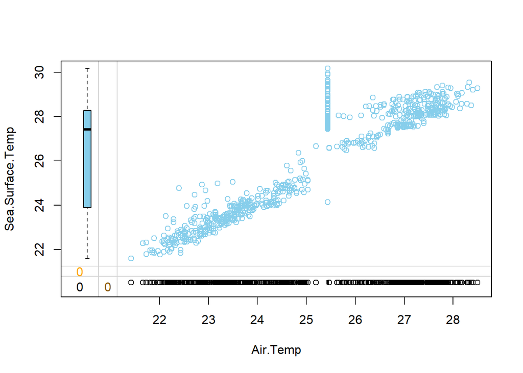

```r
# Draw a margin plot of air_temp vs sea_surface_temp
tao_imp %>%
  select(Air.Temp, Sea.Surface.Temp, air_temp_imp) %>%
  marginplot(delimiter = '_imp')
marginplot(tao_imp[,c('Air.Temp', 'Sea.Surface.Temp', 'air_temp_imp')], delimiter = '_imp')
```

The imputed values are located in the space where there is no observed data, which makes them outliers. All the imputed air_temp values are the same, no matter the sea_surface_temp. This breaks the correlation between these two variables. The variance of the imputed data differs from the one of observed data.

- assess imputation quality by marginplot from VIM package: imputed vs original data:
- after imputing, positive correlation is weaker - produce biased result

```r
# Calculate the number of missing values in air_temp per year
tao %>%
  group_by(Year) %>%
  summarize(num_miss = sum(is.na(Air.Temp)))
```

```
## # A tibble: 3 x 2
##    Year num_miss
##   <int>    <int>
## 1  1993        4
## 2  1997       77
## 3    NA     3319
```

- less variance -> increase standard error
- median can be good in the case of outlier
2. Hot-deck
3. KNN

```r
# knnOutput <- knnImputation(mydata)
# benefit: non-parametric, flexible with categorical and numeric
# cost: costly
```

```r
# imputation by mode introduces bias
# imputation by mean introduces variance



# Numeric Variable:
# 1. Linear Regression
# 2. Random Forest
# 3. MCMC

# Categorical variable:
# 1. Logistic Regression
# 2. ANOVA
# 3. KNN
# 4. MICE
# mice
```

# Model-Based

sing statistical or ML models